# Risk Factor Analysis

## Outcome Variable

**Outcome Variable:** pers_wasted624

## Predictor Variables

**Intervention Variable:** ever_sstunted06

**Adjustment Set:**

- sex
- arm
- enstunt
- month
- brthmon
- vagbrth
- single
- W_gagebrth
- W_birthwt
- W_birthlen
- W_mage
- W_mhtcm
- W_meducyrs
- W_feducyrs
- W_parity
- delta_month
- delta_brthmon
- delta_vagbrth
- delta_single
- delta_W_gagebrth
- delta_W_birthwt
- delta_W_birthlen
- delta_W_mage
- delta_W_mhtcm
- delta_W_meducyrs
- delta_W_feducyrs
- delta_W_parity

## Stratifying Variables

The analysis was stratified on these variable(s):

- studyid
- country

## Data Summary

| studyid | country | ever_sstunted06 | pers_wasted624 | n_cell | n |
| --- | --- | --- | --- | --- | --- |
| ki0047075b-MAL-ED | BANGLADESH | 0 | 0 | 208 | 239 |
| ki0047075b-MAL-ED | BANGLADESH | 0 | 1 | 16 | 239 |
| ki0047075b-MAL-ED | BANGLADESH | 1 | 0 | 13 | 239 |
| ki0047075b-MAL-ED | BANGLADESH | 1 | 1 | 2 | 239 |
| ki0047075b-MAL-ED | BRAZIL | 0 | 0 | 186 | 202 |
| ki0047075b-MAL-ED | BRAZIL | 0 | 1 | 2 | 202 |
| ki0047075b-MAL-ED | BRAZIL | 1 | 0 | 14 | 202 |
| ki0047075b-MAL-ED | BRAZIL | 1 | 1 | 0 | 202 |
| ki0047075b-MAL-ED | INDIA | 0 | 0 | 193 | 234 |
| ki0047075b-MAL-ED | INDIA | 0 | 1 | 22 | 234 |
| ki0047075b-MAL-ED | INDIA | 1 | 0 | 13 | 234 |
| ki0047075b-MAL-ED | INDIA | 1 | 1 | 6 | 234 |
| ki0047075b-MAL-ED | NEPAL | 0 | 0 | 224 | 234 |
| ki0047075b-MAL-ED | NEPAL | 0 | 1 | 2 | 234 |
| ki0047075b-MAL-ED | NEPAL | 1 | 0 | 8 | 234 |
| ki0047075b-MAL-ED | NEPAL | 1 | 1 | 0 | 234 |
| ki0047075b-MAL-ED | PERU | 0 | 0 | 231 | 264 |
| ki0047075b-MAL-ED | PERU | 0 | 1 | 1 | 264 |
| ki0047075b-MAL-ED | PERU | 1 | 0 | 31 | 264 |
| ki0047075b-MAL-ED | PERU | 1 | 1 | 1 | 264 |
| ki0047075b-MAL-ED | SOUTH AFRICA | 0 | 0 | 231 | 258 |
| ki0047075b-MAL-ED | SOUTH AFRICA | 0 | 1 | 2 | 258 |
| ki0047075b-MAL-ED | SOUTH AFRICA | 1 | 0 | 25 | 258 |
| ki0047075b-MAL-ED | SOUTH AFRICA | 1 | 1 | 0 | 258 |
| ki0047075b-MAL-ED | TANZANIA, UNITED REPUBLIC OF | 0 | 0 | 211 | 244 |
| ki0047075b-MAL-ED | TANZANIA, UNITED REPUBLIC OF | 0 | 1 | 0 | 244 |
| ki0047075b-MAL-ED | TANZANIA, UNITED REPUBLIC OF | 1 | 0 | 33 | 244 |
| ki0047075b-MAL-ED | TANZANIA, UNITED REPUBLIC OF | 1 | 1 | 0 | 244 |
| ki1000108-CMC-V-BCS-2002 | INDIA | 0 | 0 | 260 | 368 |
| ki1000108-CMC-V-BCS-2002 | INDIA | 0 | 1 | 17 | 368 |

[output cut: 118 more lines]

The following strata were considered:

- studyid: ki0047075b-MAL-ED, country: BANGLADESH
- studyid: ki0047075b-MAL-ED, country: BRAZIL
- studyid: ki0047075b-MAL-ED, country: INDIA
- studyid: ki0047075b-MAL-ED, country: NEPAL
- studyid: ki0047075b-MAL-ED, country: PERU
- studyid: ki0047075b-MAL-ED, country: SOUTH AFRICA
- studyid: ki0047075b-MAL-ED, country: TANZANIA, UNITED REPUBLIC OF
- studyid: ki1000108-CMC-V-BCS-2002, country: INDIA
- studyid: ki1000108-IRC, country: INDIA
- studyid: ki1000109-EE, country: PAKISTAN
- studyid: ki1000109-ResPak, country: PAKISTAN
- studyid: ki1000304-VITAMIN-A, country: INDIA
- studyid: ki1000304b-SAS-CompFeed, country: INDIA
- studyid: ki1000304b-SAS-FoodSuppl, country: INDIA
- studyid: ki1017093-NIH-Birth, country: BANGLADESH
- studyid: ki1017093b-PROVIDE, country: BANGLADESH
- studyid: ki1017093c-NIH-Crypto, country: BANGLADESH
- studyid: ki1066203-TanzaniaChild2, country: TANZANIA, UNITED REPUBLIC OF
- studyid: ki1101329-Keneba, country: GAMBIA
- studyid: ki1112895-Burkina Faso Zn, country: BURKINA FASO
- studyid: ki1112895-Guatemala BSC, country: GUATEMALA
- studyid: ki1113344-GMS-Nepal, country: NEPAL
- studyid: ki1114097-CMIN, country: BANGLADESH
- studyid: ki1114097-CMIN, country: BRAZIL
- studyid: ki1114097-CMIN, country: GUINEA-BISSAU
- studyid: ki1114097-CMIN, country: PERU
- studyid: ki1114097-CONTENT, country: PERU
- studyid: ki1119695-PROBIT, country: BELARUS
- studyid: ki1126311-ZVITAMBO, country: ZIMBABWE
- studyid: ki1135781-COHORTS, country: GUATEMALA
- studyid: ki1135781-COHORTS, country: INDIA
- studyid: ki1135781-COHORTS, country: PHILIPPINES
- studyid: ki1148112-iLiNS-DOSE, country: MALAWI
- studyid: ki1148112-iLiNS-DYAD-M, country: MALAWI
- studyid: ki1148112-LCNI-5, country: MALAWI
- studyid: kiGH5241-JiVitA-3, country: BANGLADESH
- studyid: kiGH5241-JiVitA-4, country: BANGLADESH

### Dropped Strata

Some strata were dropped due to rare outcomes:

- studyid: ki0047075b-MAL-ED, country: BANGLADESH
- studyid: ki0047075b-MAL-ED, country: BRAZIL
- studyid: ki0047075b-MAL-ED, country: NEPAL
- studyid: ki0047075b-MAL-ED, country: PERU
- studyid: ki0047075b-MAL-ED, country: SOUTH AFRICA
- studyid: ki0047075b-MAL-ED, country: TANZANIA, UNITED REPUBLIC OF
- studyid: ki1017093b-PROVIDE, country: BANGLADESH
- studyid: ki1112895-Burkina Faso Zn, country: BURKINA FASO
- studyid: ki1112895-Guatemala BSC, country: GUATEMALA
- studyid: ki1114097-CMIN, country: BRAZIL
- studyid: ki1114097-CMIN, country: GUINEA-BISSAU
- studyid: ki1114097-CMIN, country: PERU
- studyid: ki1114097-CONTENT, country: PERU
- studyid: ki1119695-PROBIT, country: BELARUS
- studyid: ki1148112-iLiNS-DYAD-M, country: MALAWI
- studyid: ki1148112-LCNI-5, country: MALAWI

## Methods Detail

We’re interested in the causal parameters $E[Y_a]$ for all values of $a \in \mathcal{A}$. These parameters represent the mean outcome if, possibly contrary to fact, we intervened to set all units to have $A=a$. Under the randomization and positivity assumptions, these are identified by the statistical parameters $\psi_a=E_W[E_{Y|A,W}(Y|A=a,W)]$. In addition, we’re interested in the mean of $Y$, $E[Y]$ under no intervention (the observed mean). We will estimate these parameters by using SuperLearner to fit the relevant likelihood factors – $E_{Y|A,W}(Y|A=a,W)$ and $p(A=a|W)$, and then updating our likelihood fit using a joint TMLE.

For unadjusted analyses ($W=\{\}$), initial likelihoods were estimated using Lrnr_glm to estimate the simple $E(Y|A)$ and Lrnr_mean to estimate $p(A)$. For adjusted analyses, a small library containing Lrnr_glmnet, Lrnr_xgboost, and Lrnr_mean was used.

Having estimated these parameters, we will then use the delta method to estimate relative risks and attributable risks relative to a prespecified baseline level of $A$.

# Results Detail

## Results Plots

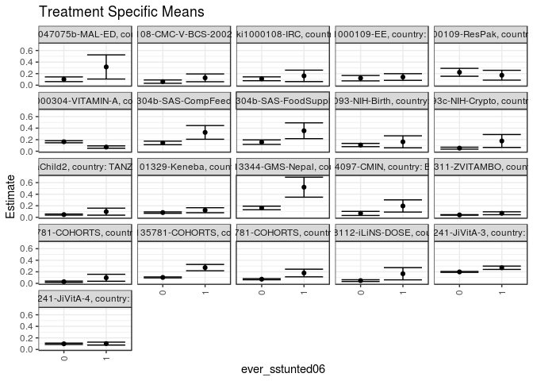

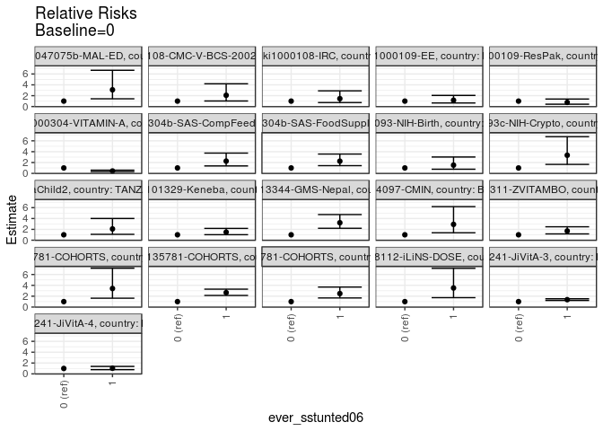

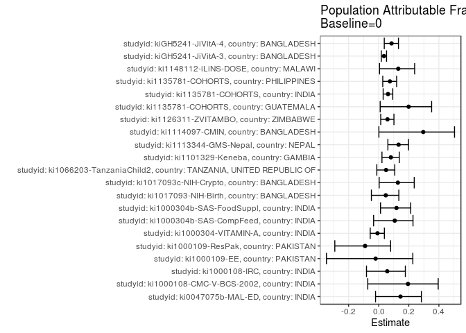

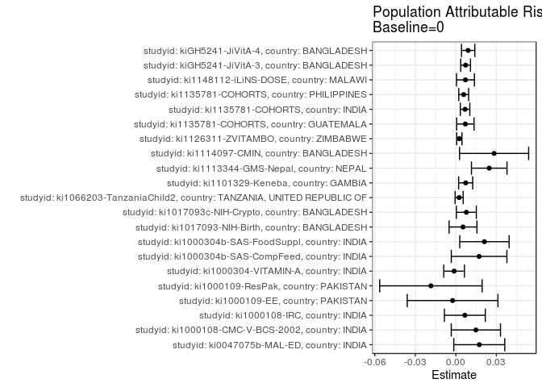

## Results Table

### Parameter: TSM

| studyid | country | intervention_level | baseline_level | estimate | ci_lower | ci_upper |
| --- | --- | --- | --- | --- | --- | --- |
| ki0047075b-MAL-ED | INDIA | 0 | NA | 0.1023256 | 0.0617270 | 0.1429241 |
| ki0047075b-MAL-ED | INDIA | 1 | NA | 0.3157895 | 0.1063324 | 0.5252465 |
| ki1000108-CMC-V-BCS-2002 | INDIA | 0 | NA | 0.0612692 | 0.0329241 | 0.0896143 |
| ki1000108-CMC-V-BCS-2002 | INDIA | 1 | NA | 0.1271521 | 0.0597303 | 0.1945740 |
| ki1000108-IRC | INDIA | 0 | NA | 0.1104137 | 0.0771925 | 0.1436349 |
| ki1000108-IRC | INDIA | 1 | NA | 0.1611154 | 0.0619804 | 0.2602503 |
| ki1000109-EE | PAKISTAN | 0 | NA | 0.1210186 | 0.0741594 | 0.1678778 |
| ki1000109-EE | PAKISTAN | 1 | NA | 0.1408708 | 0.0831439 | 0.1985977 |
| ki1000109-ResPak | PAKISTAN | 0 | NA | 0.2230150 | 0.1545213 | 0.2915087 |
| ki1000109-ResPak | PAKISTAN | 1 | NA | 0.1720843 | 0.0867649 | 0.2574037 |
| ki1000304-VITAMIN-A | INDIA | 0 | NA | 0.1640663 | 0.1465424 | 0.1815902 |
| ki1000304-VITAMIN-A | INDIA | 1 | NA | 0.0724216 | 0.0521689 | 0.0926742 |
| ki1000304b-SAS-CompFeed | INDIA | 0 | NA | 0.1440328 | 0.1133454 | 0.1747203 |
| ki1000304b-SAS-CompFeed | INDIA | 1 | NA | 0.3261987 | 0.2077788 | 0.4446186 |
| ki1000304b-SAS-FoodSuppl | INDIA | 0 | NA | 0.1576089 | 0.1187630 | 0.1964547 |
| ki1000304b-SAS-FoodSuppl | INDIA | 1 | NA | 0.3546439 | 0.2179048 | 0.4913831 |
| ki1017093-NIH-Birth | BANGLADESH | 0 | NA | 0.1075269 | 0.0793430 | 0.1357107 |
| ki1017093-NIH-Birth | BANGLADESH | 1 | NA | 0.1632653 | 0.0596763 | 0.2668543 |
| ki1017093c-NIH-Crypto | BANGLADESH | 0 | NA | 0.0531758 | 0.0362618 | 0.0700898 |
| ki1017093c-NIH-Crypto | BANGLADESH | 1 | NA | 0.1777778 | 0.0659947 | 0.2895609 |
| ki1066203-TanzaniaChild2 | TANZANIA, UNITED REPUBLIC OF | 0 | NA | 0.0470202 | 0.0373165 | 0.0567240 |
| ki1066203-TanzaniaChild2 | TANZANIA, UNITED REPUBLIC OF | 1 | NA | 0.0978261 | 0.0371050 | 0.1585472 |
| ki1101329-Keneba | GAMBIA | 0 | NA | 0.0823694 | 0.0701898 | 0.0945491 |
| ki1101329-Keneba | GAMBIA | 1 | NA | 0.1225264 | 0.0793516 | 0.1657013 |
| ki1113344-GMS-Nepal | NEPAL | 0 | NA | 0.1619460 | 0.1308873 | 0.1930047 |
| ki1113344-GMS-Nepal | NEPAL | 1 | NA | 0.5216595 | 0.3487734 | 0.6945456 |
| ki1114097-CMIN | BANGLADESH | 0 | NA | 0.0673032 | 0.0319336 | 0.1026727 |
| ki1114097-CMIN | BANGLADESH | 1 | NA | 0.1964296 | 0.0909041 | 0.3019551 |
| ki1126311-ZVITAMBO | ZIMBABWE | 0 | NA | 0.0412501 | 0.0367587 | 0.0457416 |
| ki1126311-ZVITAMBO | ZIMBABWE | 1 | NA | 0.0699998 | 0.0447135 | 0.0952860 |
| ki1135781-COHORTS | GUATEMALA | 0 | NA | 0.0283251 | 0.0169080 | 0.0397422 |
| ki1135781-COHORTS | GUATEMALA | 1 | NA | 0.0967742 | 0.0366534 | 0.1568950 |
| ki1135781-COHORTS | INDIA | 0 | NA | 0.1028618 | 0.0945698 | 0.1111538 |
| ki1135781-COHORTS | INDIA | 1 | NA | 0.2731901 | 0.2184797 | 0.3279005 |
| ki1135781-COHORTS | PHILIPPINES | 0 | NA | 0.0721790 | 0.0621829 | 0.0821752 |
| ki1135781-COHORTS | PHILIPPINES | 1 | NA | 0.1794375 | 0.1132443 | 0.2456307 |
| ki1148112-iLiNS-DOSE | MALAWI | 0 | NA | 0.0474308 | 0.0322996 | 0.0625621 |
| ki1148112-iLiNS-DOSE | MALAWI | 1 | NA | 0.1666667 | 0.0611720 | 0.2721613 |
| kiGH5241-JiVitA-3 | BANGLADESH | 0 | NA | 0.1984175 | 0.1904623 | 0.2063727 |
| kiGH5241-JiVitA-3 | BANGLADESH | 1 | NA | 0.2704305 | 0.2415804 | 0.2992805 |
| kiGH5241-JiVitA-4 | BANGLADESH | 0 | NA | 0.0974371 | 0.0855817 | 0.1092925 |
| kiGH5241-JiVitA-4 | BANGLADESH | 1 | NA | 0.1010603 | 0.0754168 | 0.1267038 |

### Parameter: E(Y)

| studyid | country | intervention_level | baseline_level | estimate | ci_lower | ci_upper |
| --- | --- | --- | --- | --- | --- | --- |
| ki0047075b-MAL-ED | INDIA | NA | NA | 0.1196581 | 0.0779840 | 0.1613323 |
| ki1000108-CMC-V-BCS-2002 | INDIA | NA | NA | 0.0760870 | 0.0489610 | 0.1032130 |
| ki1000108-IRC | INDIA | NA | NA | 0.1170732 | 0.0859146 | 0.1482317 |
| ki1000109-EE | PAKISTAN | NA | NA | 0.1185984 | 0.0856546 | 0.1515422 |
| ki1000109-ResPak | PAKISTAN | NA | NA | 0.2045455 | 0.1511224 | 0.2579685 |
| ki1000304-VITAMIN-A | INDIA | NA | NA | 0.1627604 | 0.1476839 | 0.1778369 |
| ki1000304b-SAS-CompFeed | INDIA | NA | NA | 0.1612426 | 0.1416314 | 0.1808538 |
| ki1000304b-SAS-FoodSuppl | INDIA | NA | NA | 0.1787565 | 0.1404842 | 0.2170288 |
| ki1017093-NIH-Birth | BANGLADESH | NA | NA | 0.1128405 | 0.0854611 | 0.1402198 |
| ki1017093c-NIH-Crypto | BANGLADESH | NA | NA | 0.0609418 | 0.0434802 | 0.0784034 |
| ki1066203-TanzaniaChild2 | TANZANIA, UNITED REPUBLIC OF | NA | NA | 0.0494534 | 0.0397554 | 0.0591514 |
| ki1101329-Keneba | GAMBIA | NA | NA | 0.0896333 | 0.0777184 | 0.1015482 |
| ki1113344-GMS-Nepal | NEPAL | NA | NA | 0.1866438 | 0.1550166 | 0.2182711 |
| ki1114097-CMIN | BANGLADESH | NA | NA | 0.0956175 | 0.0591654 | 0.1320697 |
| ki1126311-ZVITAMBO | ZIMBABWE | NA | NA | 0.0438186 | 0.0394817 | 0.0481556 |
| ki1135781-COHORTS | GUATEMALA | NA | NA | 0.0353591 | 0.0233199 | 0.0473983 |
| ki1135781-COHORTS | INDIA | NA | NA | 0.1096840 | 0.1017209 | 0.1176470 |
| ki1135781-COHORTS | PHILIPPINES | NA | NA | 0.0779833 | 0.0679723 | 0.0879943 |
| ki1148112-iLiNS-DOSE | MALAWI | NA | NA | 0.0545229 | 0.0388484 | 0.0701975 |
| kiGH5241-JiVitA-3 | BANGLADESH | NA | NA | 0.2056324 | 0.1980748 | 0.2131900 |
| kiGH5241-JiVitA-4 | BANGLADESH | NA | NA | 0.1065428 | 0.0957758 | 0.1173098 |

### Parameter: RR

| studyid | country | intervention_level | baseline_level | estimate | ci_lower | ci_upper |
| --- | --- | --- | --- | --- | --- | --- |
| ki0047075b-MAL-ED | INDIA | 0 | 0 | 1.0000000 | 1.0000000 | 1.0000000 |
| ki0047075b-MAL-ED | INDIA | 1 | 0 | 3.0861244 | 1.4247928 | 6.6845956 |
| ki1000108-CMC-V-BCS-2002 | INDIA | 0 | 0 | 1.0000000 | 1.0000000 | 1.0000000 |
| ki1000108-CMC-V-BCS-2002 | INDIA | 1 | 0 | 2.0753024 | 1.0267023 | 4.1948674 |
| ki1000108-IRC | INDIA | 0 | 0 | 1.0000000 | 1.0000000 | 1.0000000 |
| ki1000108-IRC | INDIA | 1 | 0 | 1.4591970 | 0.7348202 | 2.8976559 |
| ki1000109-EE | PAKISTAN | 0 | 0 | 1.0000000 | 1.0000000 | 1.0000000 |
| ki1000109-EE | PAKISTAN | 1 | 0 | 1.1640426 | 0.6604085 | 2.0517530 |
| ki1000109-ResPak | PAKISTAN | 0 | 0 | 1.0000000 | 1.0000000 | 1.0000000 |
| ki1000109-ResPak | PAKISTAN | 1 | 0 | 0.7716267 | 0.4308353 | 1.3819849 |
| ki1000304-VITAMIN-A | INDIA | 0 | 0 | 1.0000000 | 1.0000000 | 1.0000000 |
| ki1000304-VITAMIN-A | INDIA | 1 | 0 | 0.4414164 | 0.3280107 | 0.5940306 |
| ki1000304b-SAS-CompFeed | INDIA | 0 | 0 | 1.0000000 | 1.0000000 | 1.0000000 |
| ki1000304b-SAS-CompFeed | INDIA | 1 | 0 | 2.2647525 | 1.3724255 | 3.7372548 |
| ki1000304b-SAS-FoodSuppl | INDIA | 0 | 0 | 1.0000000 | 1.0000000 | 1.0000000 |
| ki1000304b-SAS-FoodSuppl | INDIA | 1 | 0 | 2.2501522 | 1.4222735 | 3.5599236 |
| ki1017093-NIH-Birth | BANGLADESH | 0 | 0 | 1.0000000 | 1.0000000 | 1.0000000 |
| ki1017093-NIH-Birth | BANGLADESH | 1 | 0 | 1.5183673 | 0.7642537 | 3.0165892 |
| ki1017093c-NIH-Crypto | BANGLADESH | 0 | 0 | 1.0000000 | 1.0000000 | 1.0000000 |
| ki1017093c-NIH-Crypto | BANGLADESH | 1 | 0 | 3.3432099 | 1.6524803 | 6.7638036 |
| ki1066203-TanzaniaChild2 | TANZANIA, UNITED REPUBLIC OF | 0 | 0 | 1.0000000 | 1.0000000 | 1.0000000 |
| ki1066203-TanzaniaChild2 | TANZANIA, UNITED REPUBLIC OF | 1 | 0 | 2.0805106 | 1.0816633 | 4.0017298 |
| ki1101329-Keneba | GAMBIA | 0 | 0 | 1.0000000 | 1.0000000 | 1.0000000 |
| ki1101329-Keneba | GAMBIA | 1 | 0 | 1.4875227 | 1.0155164 | 2.1789149 |
| ki1113344-GMS-Nepal | NEPAL | 0 | 0 | 1.0000000 | 1.0000000 | 1.0000000 |
| ki1113344-GMS-Nepal | NEPAL | 1 | 0 | 3.2211939 | 2.1967313 | 4.7234227 |
| ki1114097-CMIN | BANGLADESH | 0 | 0 | 1.0000000 | 1.0000000 | 1.0000000 |
| ki1114097-CMIN | BANGLADESH | 1 | 0 | 2.9185789 | 1.3753652 | 6.1933386 |
| ki1126311-ZVITAMBO | ZIMBABWE | 0 | 0 | 1.0000000 | 1.0000000 | 1.0000000 |
| ki1126311-ZVITAMBO | ZIMBABWE | 1 | 0 | 1.6969582 | 1.1636985 | 2.4745819 |
| ki1135781-COHORTS | GUATEMALA | 0 | 0 | 1.0000000 | 1.0000000 | 1.0000000 |
| ki1135781-COHORTS | GUATEMALA | 1 | 0 | 3.4165498 | 1.6291833 | 7.1648246 |
| ki1135781-COHORTS | INDIA | 0 | 0 | 1.0000000 | 1.0000000 | 1.0000000 |
| ki1135781-COHORTS | INDIA | 1 | 0 | 2.6558949 | 2.1406562 | 3.2951474 |
| ki1135781-COHORTS | PHILIPPINES | 0 | 0 | 1.0000000 | 1.0000000 | 1.0000000 |
| ki1135781-COHORTS | PHILIPPINES | 1 | 0 | 2.4860057 | 1.6764583 | 3.6864765 |
| ki1148112-iLiNS-DOSE | MALAWI | 0 | 0 | 1.0000000 | 1.0000000 | 1.0000000 |
| ki1148112-iLiNS-DOSE | MALAWI | 1 | 0 | 3.5138888 | 1.7296293 | 7.1387639 |
| kiGH5241-JiVitA-3 | BANGLADESH | 0 | 0 | 1.0000000 | 1.0000000 | 1.0000000 |
| kiGH5241-JiVitA-3 | BANGLADESH | 1 | 0 | 1.3629365 | 1.2163132 | 1.5272349 |
| kiGH5241-JiVitA-4 | BANGLADESH | 0 | 0 | 1.0000000 | 1.0000000 | 1.0000000 |
| kiGH5241-JiVitA-4 | BANGLADESH | 1 | 0 | 1.0371857 | 0.7814481 | 1.3766162 |

### Parameter: PAR

| studyid | country | intervention_level | baseline_level | estimate | ci_lower | ci_upper |
| --- | --- | --- | --- | --- | --- | --- |
| ki0047075b-MAL-ED | INDIA | 0 | NA | 0.0173325 | -0.0015396 | 0.0362047 |
| ki1000108-CMC-V-BCS-2002 | INDIA | 0 | NA | 0.0148178 | -0.0033908 | 0.0330263 |
| ki1000108-IRC | INDIA | 0 | NA | 0.0066595 | -0.0084748 | 0.0217938 |
| ki1000109-EE | PAKISTAN | 0 | NA | -0.0024202 | -0.0359971 | 0.0311566 |
| ki1000109-ResPak | PAKISTAN | 0 | NA | -0.0184695 | -0.0563787 | 0.0194397 |
| ki1000304-VITAMIN-A | INDIA | 0 | NA | -0.0013059 | -0.0089755 | 0.0063637 |
| ki1000304b-SAS-CompFeed | INDIA | 0 | NA | 0.0172098 | -0.0033605 | 0.0377800 |
| ki1000304b-SAS-FoodSuppl | INDIA | 0 | NA | 0.0211476 | 0.0028665 | 0.0394287 |
| ki1017093-NIH-Birth | BANGLADESH | 0 | NA | 0.0053136 | -0.0050182 | 0.0156453 |
| ki1017093c-NIH-Crypto | BANGLADESH | 0 | NA | 0.0077661 | 0.0003846 | 0.0151475 |
| ki1066203-TanzaniaChild2 | TANZANIA, UNITED REPUBLIC OF | 0 | NA | 0.0024332 | -0.0005515 | 0.0054178 |
| ki1101329-Keneba | GAMBIA | 0 | NA | 0.0072639 | 0.0020497 | 0.0124780 |
| ki1113344-GMS-Nepal | NEPAL | 0 | NA | 0.0246978 | 0.0115443 | 0.0378513 |
| ki1114097-CMIN | BANGLADESH | 0 | NA | 0.0283144 | 0.0027395 | 0.0538892 |
| ki1126311-ZVITAMBO | ZIMBABWE | 0 | NA | 0.0025685 | 0.0006273 | 0.0045097 |
| ki1135781-COHORTS | GUATEMALA | 0 | NA | 0.0070340 | 0.0006011 | 0.0134669 |
| ki1135781-COHORTS | INDIA | 0 | NA | 0.0068222 | 0.0033022 | 0.0103421 |
| ki1135781-COHORTS | PHILIPPINES | 0 | NA | 0.0058043 | 0.0021505 | 0.0094581 |
| ki1148112-iLiNS-DOSE | MALAWI | 0 | NA | 0.0070921 | 0.0004608 | 0.0137233 |
| kiGH5241-JiVitA-3 | BANGLADESH | 0 | NA | 0.0072149 | 0.0036001 | 0.0108297 |
| kiGH5241-JiVitA-4 | BANGLADESH | 0 | NA | 0.0091057 | 0.0041760 | 0.0140355 |

### Parameter: PAF

| studyid | country | intervention_level | baseline_level | estimate | ci_lower | ci_upper |
| --- | --- | --- | --- | --- | --- | --- |
| ki0047075b-MAL-ED | INDIA | 0 | NA | 0.1448505 | -0.0207766 | 0.2836036 |
| ki1000108-CMC-V-BCS-2002 | INDIA | 0 | NA | 0.1947476 | -0.0723666 | 0.3953267 |
| ki1000108-IRC | INDIA | 0 | NA | 0.0568829 | -0.0809108 | 0.1771108 |
| ki1000109-EE | PAKISTAN | 0 | NA | -0.0204068 | -0.3468269 | 0.2269014 |
| ki1000109-ResPak | PAKISTAN | 0 | NA | -0.0902954 | -0.2913276 | 0.0794403 |
| ki1000304-VITAMIN-A | INDIA | 0 | NA | -0.0080234 | -0.0561995 | 0.0379552 |
| ki1000304b-SAS-CompFeed | INDIA | 0 | NA | 0.1067321 | -0.0336189 | 0.2280254 |
| ki1000304b-SAS-FoodSuppl | INDIA | 0 | NA | 0.1183040 | 0.0122625 | 0.2129612 |
| ki1017093-NIH-Birth | BANGLADESH | 0 | NA | 0.0470894 | -0.0484184 | 0.1338966 |
| ki1017093c-NIH-Crypto | BANGLADESH | 0 | NA | 0.1274339 | 0.0032097 | 0.2361767 |
| ki1066203-TanzaniaChild2 | TANZANIA, UNITED REPUBLIC OF | 0 | NA | 0.0492015 | -0.0123635 | 0.1070224 |
| ki1101329-Keneba | GAMBIA | 0 | NA | 0.0810399 | 0.0218521 | 0.1366463 |
| ki1113344-GMS-Nepal | NEPAL | 0 | NA | 0.1323260 | 0.0611719 | 0.1980872 |
| ki1114097-CMIN | BANGLADESH | 0 | NA | 0.2961211 | 0.0014671 | 0.5038265 |
| ki1126311-ZVITAMBO | ZIMBABWE | 0 | NA | 0.0586167 | 0.0137292 | 0.1014613 |
| ki1135781-COHORTS | GUATEMALA | 0 | NA | 0.1989301 | 0.0099812 | 0.3518174 |
| ki1135781-COHORTS | INDIA | 0 | NA | 0.0621984 | 0.0298103 | 0.0935053 |
| ki1135781-COHORTS | PHILIPPINES | 0 | NA | 0.0744297 | 0.0272272 | 0.1193418 |
| ki1148112-iLiNS-DOSE | MALAWI | 0 | NA | 0.1300755 | 0.0056017 | 0.2389682 |
| kiGH5241-JiVitA-3 | BANGLADESH | 0 | NA | 0.0350864 | 0.0174644 | 0.0523925 |
| kiGH5241-JiVitA-4 | BANGLADESH | 0 | NA | 0.0854656 | 0.0371373 | 0.1313682 |